# FILTROS

### Muestra el efecto de diferentes filtros sobre la imagen en vivo de la webcam. Selecciona con el teclado el filtro deseado y modifica sus posibles parámetros (p.ej. el nivel de suavizado) con las teclas o con trackbars. Aplica el filtro en un ROI para comparar el resultado con el resto de la imagen.

Para este ejercicio se han implementado una serie de filtros que se aplicaran sobre una sección de interés con el fin de que se aprecie la diferencia entre aplicarlo o no.

El programa cuenta con 7 filtros que veremos en este notebook, en el que también cuenta con un manual de uso y ejemplos de los resultados obtenidos.

## Manual de uso

El script programado se llama `4_FILTROS.py` y se ejecuta usando la cámara principal para capturar el entorno.

Por medio del ratón seremos capaces de determinar la región de interés y usando las teclas numéricas del teclado del 1 al 7 podremos alternar entre los diferentes filtros.

Una vez en cada filtro dispondremos (para aquellos que lo implementen) uno o varios parámetros a configurar. Para configurar los parámetros usaremos las teclas `m`, `n` o `b` en función a si tiene uno, dos o tres parámetros de configuración respectivamente.

- Pulsando `1`: Aplicamos el filtro Laplaciano
- Pulsando `2`: Aplicamos el filtro Gaussiano
  - Pulsando `m` cambiamos el valor de la desviación estándar del kernel
- Pulsando `3`: Aplicamos el filtro de la Mediana
  - Pulsando `m` cambiamos el valor del tamaño de la apertura lineal
- Pulsando `4`: Aplicamos el filtro Bilateral
  - Pulsando `m` cambiamos el valor del Diametro
  - Pulsando `n` cambiamos el valor del Sigma Color
  - Pulsando `b` cambiamos el valor del Sigma Space
- Pulsando `5`: Aplicamos el filtro Erosión
  - Pulsando `m` cambiamos el valor del tamaño del núcleo
- Pulsando `6`: Aplicamos el filtro Dilatación
  - Pulsando `m` cambiamos el valor del tamaño del núcleo
- Pulsando `7`: Aplicamos el filtro Black Hat
  - Pulsando `m` cambiamos el valor del tamaño del núcleo

## Convolución

### Laplaciano

El operador Laplaciano es la suma de las segundas derivadas respecto a cada variable:

$$\nabla^2 I = \frac{\partial^2 I}{\partial x^2} + \frac{\partial^2 I}{\partial y^2}$$

Su efecto es amplificar las frecuencias altas y por tanto su aplicación deja pasar las frecuencias altas.

```python
import cv2               as cv
import matplotlib.pyplot as plt
import numpy as np

original = cv.cvtColor( cv.imread("../Images/4_FILTER/filtros.png"), cv.COLOR_BGR2RGB)
```

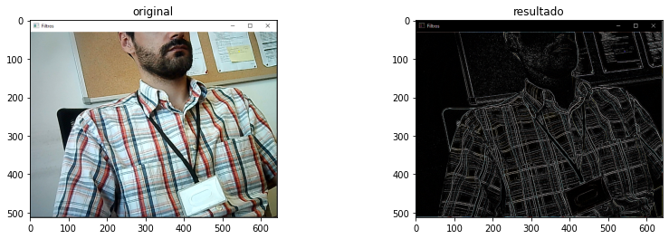

```python
# aplicación del filtro
resultado = cv.Laplacian(original,-1)
plt.figure(figsize=(14,4))
plt.subplot(1,2,1); plt.imshow(original); plt.title('original')
plt.subplot(1,2,2); plt.imshow(resultado); plt.title('resultado')
```

## Filtros de suavizado

### Gaussiano

Este filtro convoluciona la imagen de origen con el kernel gaussiano especificado. La configuración se realiza modificando el valor de la desviación estandar del kernel.

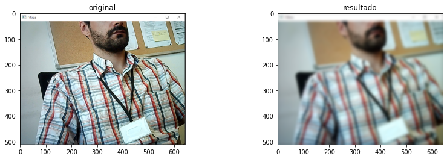

```python
# aplicación del filtro
resultado = cv.GaussianBlur(original, (0, 0), 5)
plt.figure(figsize=(14,4))
plt.subplot(1,2,1); plt.imshow(original); plt.title('original')
plt.subplot(1,2,2); plt.imshow(resultado); plt.title('resultado')
```

## Filtros no lineales

### Mediana

El filtro de mediana es no lineal siendo útil para eliminar ruido de "sal y pimienta", suavizando la imagen sin destruir los bordes.

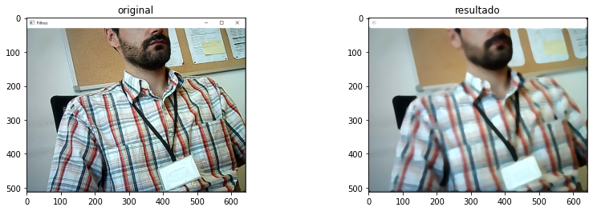

```python
# aplicación del filtro
resultado = cv.medianBlur(original, 13)
plt.figure(figsize=(14,4))
plt.subplot(1,2,1); plt.imshow(original); plt.title('original')
plt.subplot(1,2,2); plt.imshow(resultado); plt.title('resultado')
```

### Bilateral

El filtro Bilateral es muy eficaz en la eliminación de ruido y mantiene los bordes nítidos. Pero el funcionamiento es más lento en comparación con otros filtros.

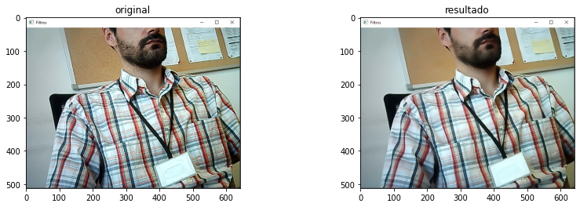

```python
# aplicación del filtro
resultado = cv.bilateralFilter(original, 15, 100, 10)
plt.figure(figsize=(14,4))
plt.subplot(1,2,1); plt.imshow(original); plt.title('original')
plt.subplot(1,2,2); plt.imshow(resultado); plt.title('resultado')
```

## Filtros Morfológicos

### Erosión

Se ha querido ampliar la galería de filtros con los filtros morfológicos[1](https://docs.opencv.org/master/d9/d61/tutorial_py_morphological_ops.html#gsc.tab=0). Las transformaciones morfológicas son algunas operaciones simples basadas en la forma de la imagen. Normalmente se realiza sobre imágenes binarias.

La idea básica de la erosión es como la erosión del suelo solamente, erosiona los límites del objeto en primer plano

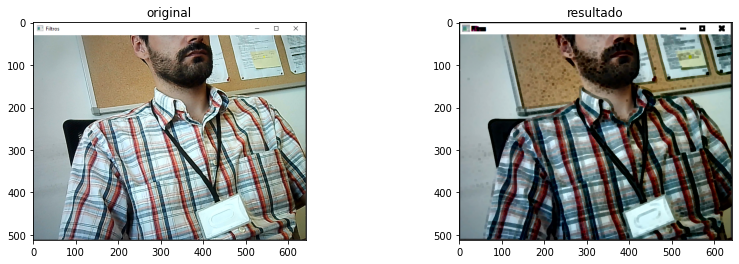

```python
# aplicación del filtro
kernel = np.ones((5, 5), np.uint8)
resultado = cv.erode(original, kernel, iterations=1)
plt.figure(figsize=(14,4))
plt.subplot(1,2,1); plt.imshow(original); plt.title('original')
plt.subplot(1,2,2); plt.imshow(resultado); plt.title('resultado')
```

### Dilatación

Es justo lo opuesto a la erosión. Aquí, un elemento de píxel es '1' si al menos un píxel debajo del núcleo es '1'. Por lo tanto, aumenta la región blanca en la imagen o aumenta el tamaño del objeto en primer plano.

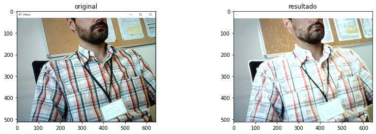

```python
# aplicación del filtro
kernel = np.ones((5, 5), np.uint8)
resultado = cv.dilate(original, kernel, iterations=1)
plt.figure(figsize=(14,4))
plt.subplot(1,2,1); plt.imshow(original); plt.title('original')
plt.subplot(1,2,2); plt.imshow(resultado); plt.title('resultado')
```

### Black Hat

Es la diferencia entre el cierre de la imagen de entrada y la imagen de entrada. Obtiuene un efecto similar al filtro Laplaciano pero funciona de diferente manera.

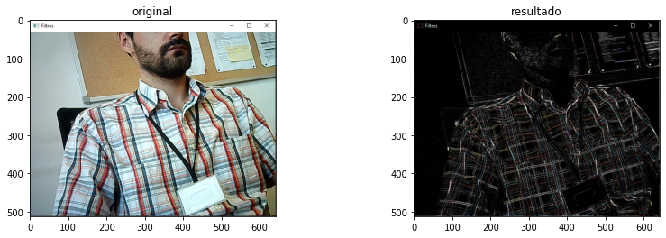

```python
# aplicación del filtro
kernel = np.ones((5, 5), np.uint8)
resultado = cv.morphologyEx(original, cv.MORPH_BLACKHAT, kernel)
plt.figure(figsize=(14,4))
plt.subplot(1,2,1); plt.imshow(original); plt.title('original')
plt.subplot(1,2,2); plt.imshow(resultado); plt.title('resultado')
```

## Resultado

Para cada filtro se muestra una serie de etiquetas que nos informan de el filtro que estamos aplicando. Así como de los valores que toman sus parámetros.

En el vídeo de ejemplo se ejecutan todos los filtros con sus correspondientes modificaciones y se puede observar como varía la imagen con cada una.

```python
from IPython.display import HTML

HTML("""
    <video alt="test" idth="320" height="240"  controls>
        <source src="../Images/4_FILTER/FILTROS.mp4" type="video/mp4">
    </video>
""")
```

[video not shown]